On 2017, I began analyzing mobile device releases and the change of resolution over the years. This is the 3rd iteration of that. You can check the last one here - [(Resolution Wars: Q1 2018 Update)](https://jotayu.com/tech/2018/05/09/Phone_Resolution/) . It’s been almost 9 months since that article and I think its about time we revisit it and get the full status of 2018.

### Resolution categorization

For categorizing myriad of resolution, I have divided them in six broad categories with little help from this Wikipedia [page](https://en.wikipedia.org/wiki/Graphics_display_resolution).

| Category | Lower.Limit.Megapixels. | Upper.Limit.Megapixels. |
| --- | --- | --- |
| 1. Below nHD | 0 | 0.22 |
| 2. nHD | 0.23 | 0.51 |
| 3. qHD | 0.52 | 0.91 |
| 4. HD | 0.92 | 2.06 |
| 5. FHD | 2.07 | 3.68 |
| 6. Quad HD | 3.69 | 3.69+ |

So, a phone having a resolution of 1200x1920 (2.3 Megapixels) will be lumped in FHD category because it has got more pixels than FHD(1080x1920 or 2.07 Megapixels) but less than Quad HD (1440x2560 or 3.69 Megapixels).

### Visualization

With all challenges solved, our dataset looks like this-

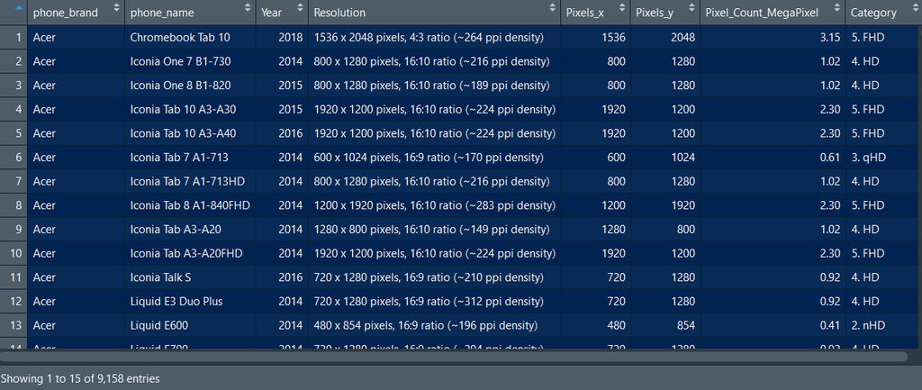

Lets first plot a stack chart with number of devices in each category since the advent of time (or more precisely, since they started tracking them).

[interactive chart not shown]

> Last time, I predicted 10-12% decrease in 2018 compared to 2017 as manufacturers continue to consolidate and simplify their offerings. Guess what it was bang on with number of device releases decreased by 11.2% to be exact.

From numbers to share of total devices by resolution category.

[interactive chart not shown]

> It is business as usual. FHD maintained its lead on HD over full year as it did in Q1’18 result.

Q1’18 gave us a surprise twist where qHD devices seemed to be making a comeback with increase in share but as we can see from full year picture, that was just an anomaly.

Here is the same with picture in stacked column chart for a different take on the same visualization.

[interactive chart not shown]

### End Notes

So, a trend with not much twist - HD is slowly becoming old school as FHD is accelerating. The upward tick in lower resolution devices in Q1’18 is found to be a one time beep as over the one year period, the trend seems to be moving down as general consensus dictates.

That’s it for today. Stay tuned and keep on commenting and sharing your views.

If you got a data-related challenge worth solving, you can knock me in the links mentioned in profile section and may be we can help each other out.